# Introduction to DESeq2

Stacey Borrego

5/09/2018

## Exploratory Data Analysis and Differential Expression

**Exploratory Data Analysis (EDA)**

Analyzing data sets to summarize their main characteristics, usually through visualization. Read more on [Wikipedia](https://en.wikipedia.org/wiki/Exploratory_data_analysis).

**Differential Expression (DE)**

Differential expression analysis is a statistical approach to identify changes in gene expression between different experimental groups.

*Program Considerations*

- Pair wise comparison
- Multiple comparison - edgeR, limma-voom, DESeq2, maSigPro
- Bayesian - baySeq, EBSeq

*Comparison Articles*

- [Mike Love’s Blog: DESeq2 or edgeR](https://mikelove.wordpress.com/2016/09/28/deseq2-or-edger/)
- [How many biological replicates are needed in an RNA-seq experiment and which differential expression tool should you use?](http://rnajournal.cshlp.org/content/early/2016/03/30/rna.053959.115.full.pdf+html) 2016 Schurch et al.

## DESeq2

DESEq2 is a tool for differential gene analysis of count data.

*Helpful Resources*

- [Moderated estimation of fold change and dispersion for RNA-seq data with DESeq2](https://genomebiology.biomedcentral.com/articles/10.1186/s13059-014-0550-8)
- [DESeq2 Manual](http://www.bioconductor.org/packages/release/bioc/manuals/DESeq2/man/DESeq2.pdf)
- [Analyzing RNA-seq data with DESeq2, 4/30/18](http://www.bioconductor.org/packages/release/bioc/vignettes/DESeq2/inst/doc/DESeq2.html)
- [RNA-seq workflow: gene-level exploratory analysis and differential expression - Timecourse tutorial included](http://master.bioconductor.org/packages/release/workflows/vignettes/rnaseqGene/inst/doc/rnaseqGene.html)
- [Differential expression of RNA-Seq data at the gene level – the DESeq package](http://bioconductor.org/packages/release/bioc/vignettes/DESeq/inst/doc/DESeq.pdf)

## SummarizedExperiment

Bioconductor generally uses ExpressionSet and SummarizedExperiment as data containers. These are generally large data matrices with metadata surrounding them.

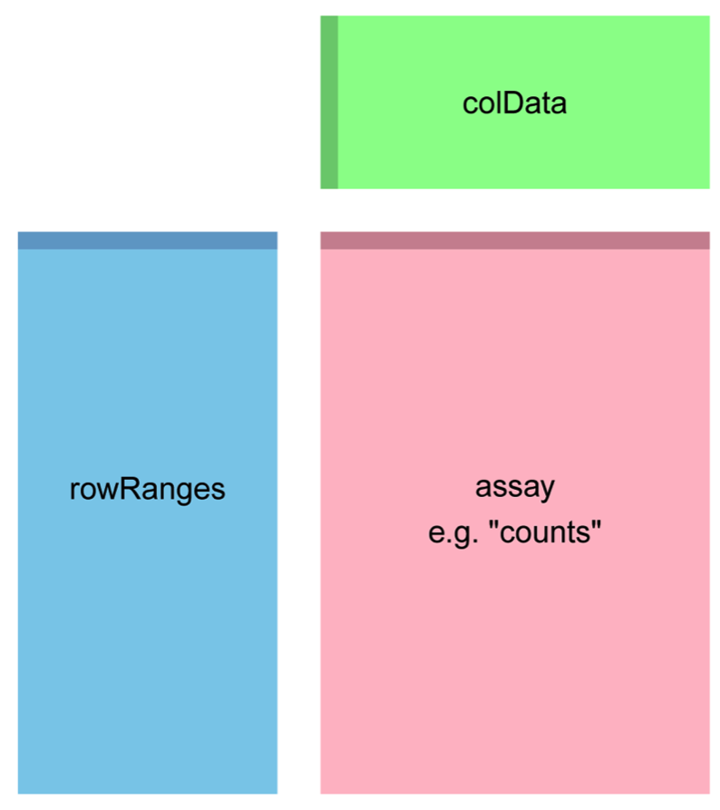

Figure 1. The component parts of a SummarizedExperiment object. The assay (pink block) contains the matrix of counts, the rowRanges (blue block) contains information about the genomic ranges and the colData (green block) contains information about the samples. The highlighted line in each block represents the first row (note that the first row of colData lines up with the first column of the assay).  
Love MI, Anders S, Kim V and Huber W. RNA-Seq workflow: gene-level exploratory analysis and differential expression [version 2]. F1000Research 2016, 4:1070 (doi: 10.12688/f1000research.7035.2)

- [STHDA: ExpressionSet and SummarizedExperiment](http://www.sthda.com/english/wiki/expressionset-and-summarizedexperiment)

## Packages for today

```r
source("https://bioconductor.org/biocLite.R")

# Dataframe manipulation
install.packages(c("dplyr", "tibble"))

# Exploratory Data Analysis tools
biocLite(c("EDAseq", "DESeq2"))

# Annotation
biocLite(c("AnnotationDbi", "org.Hs.eg.db"))

# Visualization
install.packages(c("pheatmap", "RColorBrewer", "gplots"))
```

## File Preparation

**Count data file**

- Data input should be raw counts of sequencing reads/fragment
- If necessary, combine count data from multiple sample files
- Ensure column names are correct
- Row names should be the gene name/ID
- Optional: filter for minimum read counts

**Metafile for the samples in the count file**

- Sample name
- Cell type
- Treatment/condition
- Time point
- Anything: read number, library barcode, data run, …

## Data input to DESeq2 should be **raw counts**

“The values in the matrix should be raw counts of sequencing reads/fragments. This is important for DESeq2’s statistical model to hold, as only counts allow assessing the measurement precision correctly. It is important to never provide counts that were pre-normalized for sequencing depth/library size, as the statistical model is most powerful when applied to un-normalized counts, and is designed to account for library size differences internally.”

Love MI, Anders S, Kim V and Huber W. RNA-Seq workflow: gene-level exploratory analysis and differential expression [version 2; referees: 2 approved]. F1000Research 2016, 4:1070 (doi: 10.12688/f1000research.7035.2)

When using DESeq2 spike-in data, you provide the raw counts and the calculated spike-in value. For example, using RUVseq with the ERCC spike-in, you include the factor of unwanted variation (e.g. W_1) with the raw count data.

## Count files generated by STAR

The count file I have provided was generated from the STAR alignment results on the Griffith data set.

The combined count files include:

```
 HBR_1.starReadsPerGene.out.tab
 HBR_2.starReadsPerGene.out.tab
 HBR_3.starReadsPerGene.out.tab
 UHR_1.starReadsPerGene.out.tab
 UHR_2.starReadsPerGene.out.tab
 UHR_3.starReadsPerGene.out.tab
```

## Getting the data

```r
# Change the directory path that contains the GitHub files
dir <- "/Users/stacey/Data/GitHub/Introduction-to-DESeq2"

setwd(dir)
data<- read.table("count_file_complete.txt",
                  row.names = 1,
                  header = TRUE)
head(data)
```

```
##                   HBR_1 HBR_2 HBR_3 UHR_1 UHR_2 UHR_3
## ENSG00000277248.1     0     0     0     0     0     0
## ENSG00000274237.1     0     0     0     0     0     0
## ENSG00000280363.1     0     0     0     0     0     0
## ENSG00000279973.1     0     0     0     0     0     0
## ENSG00000226444.2     0     0     0     0     0     0
## ENSG00000276871.1     0     0     0     0     0     0
```

```r
tail(data)
```

```
##            HBR_1 HBR_2 HBR_3 UHR_1 UHR_2 UHR_3
## ERCC-00163     5     7    13     6     4     9
## ERCC-00164     0     1     0     0     0     0
## ERCC-00165    33    64    41    51    28    37
## ERCC-00168     2     1     1     0     1     0
## ERCC-00170     1     2     3    18    14    15
## ERCC-00171   916  1253  1056  1903  1336  1654
```

## Removing spike-ins

The Griffith dataset includes the ERCC spike-in using Spike Mix 1 for one set of samples and Spike Mix 2 for the second set. The samples can be normalized using the two spike-in method with the package [ERCC Dashboard](https://www.bioconductor.org/packages/release/bioc/html/erccdashboard.html) available on Bioconductor.

Using the two spike-in method means that the values of the spike-ins will be different between the two groups and many will be identified as significant. I am just going to remove the spike-ins for our plotting purposes.

```r
library(dplyr)
library(tibble)
tail(data)
```

```
##            HBR_1 HBR_2 HBR_3 UHR_1 UHR_2 UHR_3
## ERCC-00163     5     7    13     6     4     9
## ERCC-00164     0     1     0     0     0     0
## ERCC-00165    33    64    41    51    28    37
## ERCC-00168     2     1     1     0     1     0
## ERCC-00170     1     2     3    18    14    15
## ERCC-00171   916  1253  1056  1903  1336  1654
```

```r
ercc_n <- length(which(grepl("ERCC", rownames(data))))
nrow(data)
```

```
## [1] 1463
```

```r
data <- data %>%
  rownames_to_column("gene") %>%
  filter(!grepl("ERCC", rownames(data))) %>%
  column_to_rownames("gene")

nrow(data)
```

```
## [1] 1371
```

```r
nrow(data) + ercc_n
```

```
## [1] 1463
```

```r
tail(data)
```

```
##                    HBR_1 HBR_2 HBR_3 UHR_1 UHR_2 UHR_3
## ENSG00000225929.1      0     2     1     0     1     0
## ENSG00000100312.10     0     0     0     0     2     0
## ENSG00000254499.1      0     0     0     0     0     0
## ENSG00000213683.4      0     0     0     0     0     0
## ENSG00000184319.15    39    58    49    31    23    33
## ENSG00000079974.17    71    61    51    64    45    46
```

## Filter the data

There are a lot of samples with zero reads and oftentimes this can be problematic. To avoid any issues during the analysis I am going to filter the data so that each sample has at least one read for each gene.

```r
min_reads <- 1
min_samples <- 6

read_filter <- apply(data,
                     1,
                     function(samples) {
                       length(which(samples >= min_reads)) >= min_samples
                       })
filtered_data <- data[read_filter, ]
head(filtered_data)
```

```
##                    HBR_1 HBR_2 HBR_3 UHR_1 UHR_2 UHR_3
## ENSG00000206195.10    10     4     8   185   154   173
## ENSG00000100181.21    19    23    20   141    93   121
## ENSG00000280156.1      1     1     1     4    40     4
## ENSG00000237438.6     22    27    32    31    27    24
## ENSG00000273203.1      7     6     4     3     3     4
## ENSG00000177663.13    58    64    58    95    70    82
```

## Filtered Data

Here are the results of the number of genes in the dataset before and after filtering.

```r
# How many genes are in the unfiltered data file?
nrow(data)
```

```
## [1] 1371
```

```r
# How many genes are in the filtered data file?
nrow(filtered_data)
```

```
## [1] 461
```

```r
# How many genes were removed?
nrow(data) - nrow(filtered_data)
```

```
## [1] 910
```

## Preparing Sample Metadata

It is important to keep an information sheet about your samples. This will help you remember what is going on with each sample and it will make it easier to assign different conditions and groups for exploratory data analysis.

```r
sample_list <- data.frame(row.names = colnames(filtered_data),
                          sample_name = colnames(filtered_data),
                          cell_type = rep(c("HBR", "UHR"), each = 3))
sample_list
```

```
##       sample_name cell_type
## HBR_1       HBR_1       HBR
## HBR_2       HBR_2       HBR
## HBR_3       HBR_3       HBR
## UHR_1       UHR_1       UHR
## UHR_2       UHR_2       UHR
## UHR_3       UHR_3       UHR
```

```r
# write.csv(sample_list, file = "sample_list.csv")
```

## Quality Assessment

It is important to check our data for anything that may look suspicious and concerning. Using the package [EDASeq](http://bioconductor.org/packages/release/bioc/html/EDASeq.html), we can make a few plots to see what our data looks like. **Step 1** is to put our data into an ExpressionSet.

```r
library("EDASeq")

set <- newSeqExpressionSet(as.matrix(filtered_data),
                           phenoData = sample_list)
set
```

```
## SeqExpressionSet (storageMode: lockedEnvironment)
## assayData: 461 features, 6 samples
##   element names: counts, normalizedCounts, offset
## protocolData: none
## phenoData
##   sampleNames: HBR_1 HBR_2 ... UHR_3 (6 total)
##   varLabels: sample_name cell_type
##   varMetadata: labelDescription
## featureData: none
## experimentData: use 'experimentData(object)'
## Annotation:
```

## Quality Assessment: RLE

Relative log expression (RLE) plots allow for the visualization of unwanted variation in large data sets. Read more about RLE plots in [RLE plots: Visualizing unwanted variation in high dimensional data](http://journals.plos.org/plosone/article?id=10.1371/journal.pone.0191629).

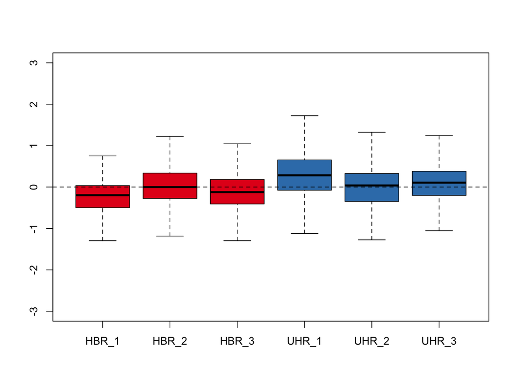

```r
library("RColorBrewer")

colors <- brewer.pal(3, "Set1")

plotRLE(set,
        outline = FALSE,
        ylim = c(-3, 3),
        col = colors[sample_list$cell_type])
```

## Quality Assessment: PCA

A PCA plot is used to emphasize variation between populations and visualize strong patterns in a dataset.

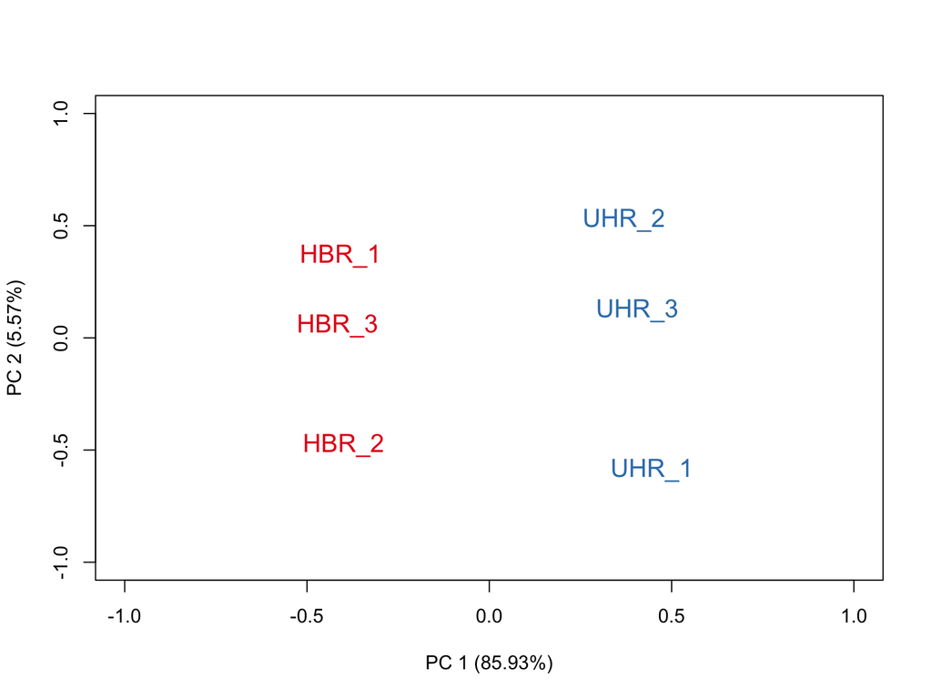

```r
plotPCA(set,
        ylim = c(-1, 1),
        xlim = c(-1, 1),
        col = colors[sample_list$cell_type],
        cex = 1.3)
```

## Count Matrix Input

From [Analyzing RNA-seq data with DESeq2, 5/04/18](http://bioconductor.org/packages/devel/bioc/vignettes/DESeq2/inst/doc/DESeq2.html#input-data)

Similar to the ExpressionSet described earlier, DESeq2 has its own data container called a **DESeqDataSet**. There are several inputs that can be converted into this type of object, see the link above for more options. Here we are using our `filtered_data` matrix as input.

```r
library("DESeq2")

ddsM <- DESeqDataSetFromMatrix(countData = filtered_data,
                               colData = sample_list,
                               design = ~ cell_type)
ddsM
```

```
## class: DESeqDataSet
## dim: 461 6
## metadata(1): version
## assays(1): counts
## rownames(461): ENSG00000206195.10 ENSG00000100181.21 ...
##   ENSG00000184319.15 ENSG00000079974.17
## rowData names(0):
## colnames(6): HBR_1 HBR_2 ... UHR_2 UHR_3
## colData names(2): sample_name cell_type
```

Alternatively, we can access the counts matrix from the ExpressionSet generated earlier and use it as an input to DESeqDataSet.

```r
ddsFromSet <- DESeqDataSetFromMatrix(countData = counts(set),
                                      colData = sample_list,
                                      design = ~ cell_type)
```

## Setting Factor levels

The sample set to be used as a reference or the levels you want a multi-factor experiment to be assigned need to be explicitly set. DESeq2 does not know what you want to use as your control but it will make a default decision and do it alphabetically. The data set we are using is comparing two different cell lines. I will set the cell line **HBR** as the reference, this will be like an “untreated” sample.

You can assign the reference using `relevel` or assign the levels using `factor`.

```r
# Explicitly set the factors levels using "factor"
# ddsM$cell_type <- factor(ddsM$cell_type, levels = c("HBR, "UHR"))

# Set the reference using "relevel"
ddsM$cell_type <- relevel(ddsM$cell_type, ref = "HBR")
```

## Differential Expression Analysis

Perform the differential analysis with the function `DESeq`.

Generate results tables using the function `results`.

```r
dds <- DESeq(ddsM)
res <- results(dds)
head(res)
```

```
## log2 fold change (MLE): cell type UHR vs HBR
## Wald test p-value: cell type UHR vs HBR
## DataFrame with 6 rows and 6 columns
##                     baseMean log2FoldChange     lfcSE       stat
##                    <numeric>      <numeric> <numeric>  <numeric>
## ENSG00000206195.10 76.530852    4.080019917 0.3505660 11.6383788
## ENSG00000100181.21 61.339964    2.050151503 0.2560161  8.0079013
## ENSG00000280156.1   8.225769    3.710366826 1.4950289  2.4818027
## ENSG00000237438.6  27.218249   -0.441750784 0.3235108 -1.3654902
## ENSG00000273203.1   4.737585   -1.225809407 0.7752010 -1.5812795
## ENSG00000177663.13 69.372029   -0.008617328 0.2073093 -0.0415675
##                          pvalue         padj
##                       <numeric>    <numeric>
## ENSG00000206195.10 2.629665e-31 3.426299e-30
## ENSG00000100181.21 1.166825e-15 6.713033e-15
## ENSG00000280156.1  1.307196e-02 2.506874e-02
## ENSG00000237438.6  1.720990e-01 2.428021e-01
## ENSG00000273203.1  1.138141e-01 1.686276e-01
## ENSG00000177663.13 9.668435e-01 9.801182e-01
```

## Dissecting the Results

```r
res_info <- data.frame(column_name = colnames(res),
                       description = mcols(res)$description)
res_info
```

```
##      column_name                                  description
## 1       baseMean    mean of normalized counts for all samples
## 2 log2FoldChange log2 fold change (MLE): cell type UHR vs HBR
## 3          lfcSE         standard error: cell type UHR vs HBR
## 4           stat         Wald statistic: cell type UHR vs HBR
## 5         pvalue      Wald test p-value: cell type UHR vs HBR
## 6           padj                         BH adjusted p-values
```

```r
counts(dds, normalized = TRUE)[1, 1:6]
```

```
##      HBR_1      HBR_2      HBR_3      UHR_1      UHR_2      UHR_3
##  12.828407   4.093501   9.517363 130.959390 152.352388 149.434064
```

```r
mean(counts(dds, normalized = TRUE)[1, 1:6])
```

```
## [1] 76.53085
```

```r
res$baseMean[1]
```

```
## [1] 76.53085
```

## A closer look at the results

```r
summary(res)
```

```
##
## out of 461 with nonzero total read count
## adjusted p-value < 0.1
## LFC > 0 (up)     : 131, 28%
## LFC < 0 (down)   : 141, 31%
## outliers [1]     : 0, 0%
## low counts [2]   : 18, 3.9%
## (mean count < 2)
## [1] see 'cooksCutoff' argument of ?results
## [2] see 'independentFiltering' argument of ?results
```

## Accessing the Data

```r
# Count Data
assay(dds)
assays(dds)[["counts"]]

# Metadata
colData(dds)

# Specific metadata column
dds$cell_type

# Information about variables and tests used
mcols(res)$description

# Specific column in the result set
res$padj
res[, c("log2FoldChange", "padj")]
```

## Ordered pvalues

```r
resOrdered <- res[order(res$padj), ]
head(resOrdered)
```

```
## log2 fold change (MLE): cell type UHR vs HBR
## Wald test p-value: cell type UHR vs HBR
## DataFrame with 6 rows and 6 columns
##                     baseMean log2FoldChange     lfcSE      stat
##                    <numeric>      <numeric> <numeric> <numeric>
## ENSG00000100321.14  525.5627      -4.615728 0.1535709 -30.05602
## ENSG00000100167.19  483.8406      -4.557954 0.1579825 -28.85100
## ENSG00000128245.14  793.7658      -2.530683 0.1018118 -24.85649
## ENSG00000100095.18  271.1757      -5.095175 0.2245764 -22.68794
## ENSG00000008735.13  282.9421      -5.666527 0.2567484 -22.07035
## ENSG00000251322.7   244.1196      -4.001964 0.1820037 -21.98837
##                           pvalue          padj
##                        <numeric>     <numeric>
## ENSG00000100321.14 1.821843e-198 8.070766e-196
## ENSG00000100167.19 4.922403e-183 1.090312e-180
## ENSG00000128245.14 2.200201e-136 3.248963e-134
## ENSG00000100095.18 5.893642e-114 6.527209e-112
## ENSG00000008735.13 6.091280e-108 5.396874e-106
## ENSG00000251322.7  3.721268e-107 2.747536e-105
```

## pvalues continued

```r
counts(dds)[rownames(counts(dds)) == "ENSG00000100321.14", ]
```

```
## HBR_1 HBR_2 HBR_3 UHR_1 UHR_2 UHR_3
##   762   995   868    54    51    42
```

```r
counts(dds, normalized = TRUE)[rownames(counts(dds)) == "ENSG00000100321.14", ]
```

```
##      HBR_1      HBR_2      HBR_3      UHR_1      UHR_2      UHR_3
##  977.52462 1018.25830 1032.63391   38.22598   50.45436   36.27879
```

```r
mean(counts(dds, normalized = TRUE)[rownames(counts(dds)) == "ENSG00000100321.14", ])
```

```
## [1] 525.5627
```

## pvalues continued

```r
sum(res$padj < 0.1, na.rm = TRUE)
```

```
## [1] 272
```

```r
sum(res$padj < 0.5, na.rm = TRUE)
```

```
## [1] 358
```

## Visualizing the Data

## pvalue distribution

Here is a quick blog post about [interpreting this type of graph](http://varianceexplained.org/statistics/interpreting-pvalue-histogram/).

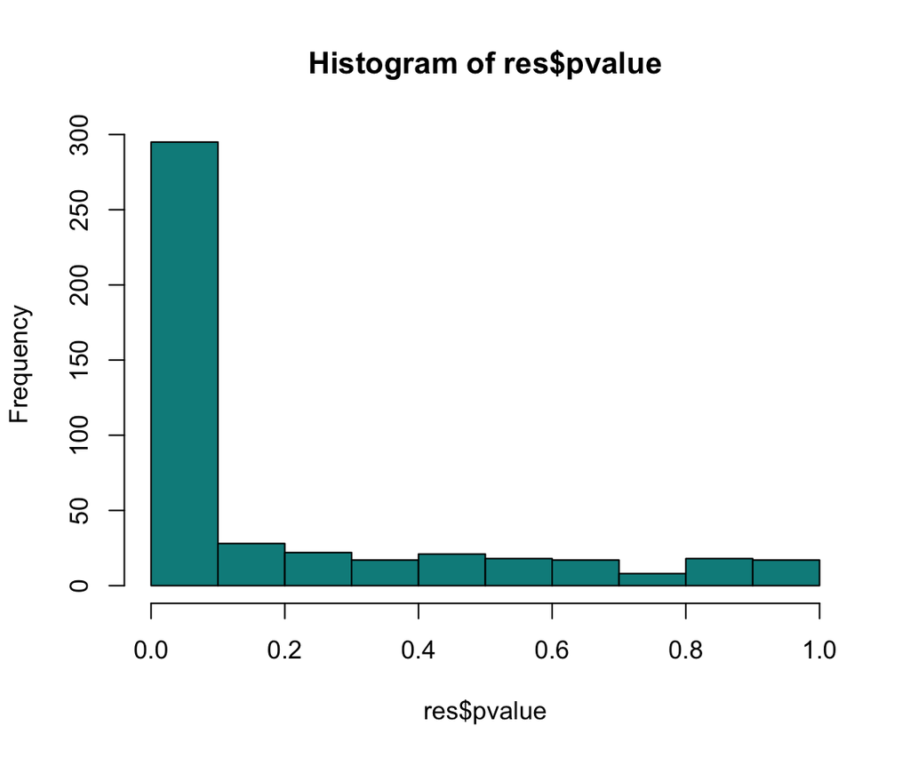

```r
hist(res$pvalue,
     col = "cyan4")
```

## Distances

A heatmap of the sample distances allows us to visualize the similarities and dissimilarities between samples.

```r
sampleDists <- dist(t(assay(dds)))
sampleDists
```

```
##           HBR_1     HBR_2     HBR_3     UHR_1     UHR_2
## HBR_2  880.7514
## HBR_3  484.3707  563.8688
## UHR_1 5481.6550 5452.3973 5441.0006
## UHR_2 3349.6318 3663.9015 3454.9287 2739.1696
## UHR_3 4163.4476 4295.0317 4189.2592 1599.7097 1195.3740
```

```r
sampleDistMatrix <- as.matrix(sampleDists)
sampleDistMatrix
```

```
##           HBR_1     HBR_2     HBR_3    UHR_1    UHR_2    UHR_3
## HBR_1    0.0000  880.7514  484.3707 5481.655 3349.632 4163.448
## HBR_2  880.7514    0.0000  563.8688 5452.397 3663.901 4295.032
## HBR_3  484.3707  563.8688    0.0000 5441.001 3454.929 4189.259
## UHR_1 5481.6550 5452.3973 5441.0006    0.000 2739.170 1599.710
## UHR_2 3349.6318 3663.9015 3454.9287 2739.170    0.000 1195.374
## UHR_3 4163.4476 4295.0317 4189.2592 1599.710 1195.374    0.000
```

## Visualizing Distances

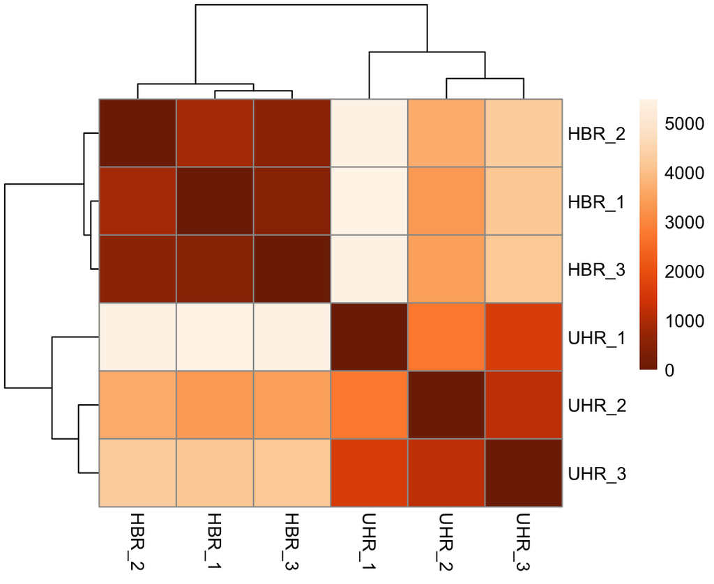

```r
library("pheatmap")
library("RColorBrewer")

colors <- colorRampPalette(rev(brewer.pal(9, "Oranges")))(200)

pheatmap(sampleDistMatrix,
         clustering_distance_rows = sampleDists,
         clustering_distance_cols = sampleDists,
         col = colors)
```

## Outliers

```r
summary(res)
```

```
##
## out of 461 with nonzero total read count
## adjusted p-value < 0.1
## LFC > 0 (up)     : 131, 28%
## LFC < 0 (down)   : 141, 31%
## outliers [1]     : 0, 0%
## low counts [2]   : 18, 3.9%
## (mean count < 2)
## [1] see 'cooksCutoff' argument of ?results
## [2] see 'independentFiltering' argument of ?results
```

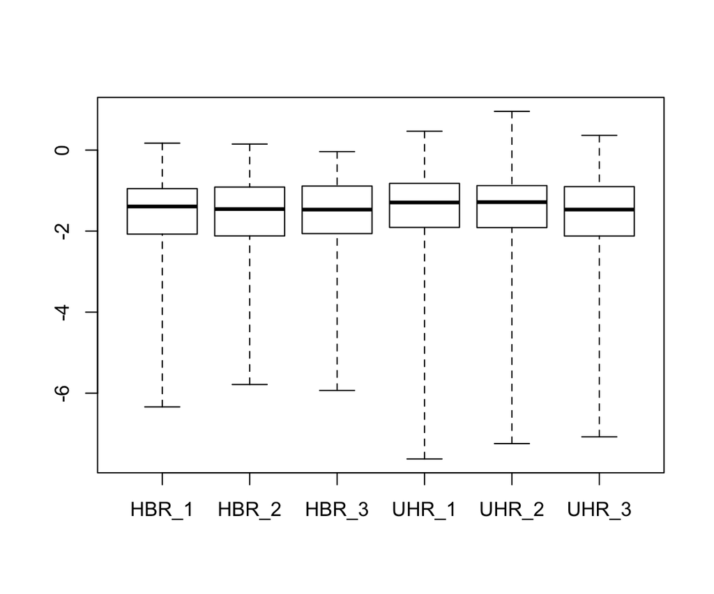

```r
boxplot(log10(assays(dds)[["cooks"]]), range = 0)
```

## Annotation

```r
library("AnnotationDbi")
library("org.Hs.eg.db")
columns(org.Hs.eg.db)
```

```
##  [1] "ACCNUM"       "ALIAS"        "ENSEMBL"      "ENSEMBLPROT"
##  [5] "ENSEMBLTRANS" "ENTREZID"     "ENZYME"       "EVIDENCE"
##  [9] "EVIDENCEALL"  "GENENAME"     "GO"           "GOALL"
## [13] "IPI"          "MAP"          "OMIM"         "ONTOLOGY"
## [17] "ONTOLOGYALL"  "PATH"         "PFAM"         "PMID"
## [21] "PROSITE"      "REFSEQ"       "SYMBOL"       "UCSCKG"
## [25] "UNIGENE"      "UNIPROT"
```

```r
# The current gene IDs have an isoform value at the end which is a provlem for
# mapping annotations. I am using gsub to remove the isoform values that
# follow a "." from the end of each gene ID.
rownames(res) <- gsub("\\..*", "", row.names(res))

res$symbol <- mapIds(org.Hs.eg.db,
                     keys = row.names(res),
                     column = "SYMBOL",
                     keytype = "ENSEMBL",
                     multiVals = "first")
res$entrez <- mapIds(org.Hs.eg.db,
                     keys = row.names(res),
                     column = "ENTREZID",
                     keytype = "ENSEMBL",
                     multiVals = "first")
res$name <- mapIds(org.Hs.eg.db,
                     keys = row.names(res),
                     column = "GENENAME",
                     keytype = "ENSEMBL",
                     multiVals = "first")
head(res)
```

```
## log2 fold change (MLE): cell type UHR vs HBR
## Wald test p-value: cell type UHR vs HBR
## DataFrame with 6 rows and 9 columns
##                  baseMean log2FoldChange     lfcSE       stat       pvalue
##                 <numeric>      <numeric> <numeric>  <numeric>    <numeric>
## ENSG00000206195 76.530852    4.080019917 0.3505660 11.6383788 2.629665e-31
## ENSG00000100181 61.339964    2.050151503 0.2560161  8.0079013 1.166825e-15
## ENSG00000280156  8.225769    3.710366826 1.4950289  2.4818027 1.307196e-02
## ENSG00000237438 27.218249   -0.441750784 0.3235108 -1.3654902 1.720990e-01
## ENSG00000273203  4.737585   -1.225809407 0.7752010 -1.5812795 1.138141e-01
## ENSG00000177663 69.372029   -0.008617328 0.2073093 -0.0415675 9.668435e-01
##                         padj      symbol      entrez
##                    <numeric> <character> <character>
## ENSG00000206195 3.426299e-30      DUXAP8      503637
## ENSG00000100181 6.713033e-15      TPTEP1      387590
## ENSG00000280156 2.506874e-02          NA          NA
## ENSG00000237438 2.428021e-01       CECR7   100130418
## ENSG00000273203 1.686276e-01          NA          NA
## ENSG00000177663 9.801182e-01      IL17RA       23765
##                                                                                 name
##                                                                          <character>
## ENSG00000206195                                       double homeobox A pseudogene 8
## ENSG00000100181          transmembrane phosphatase with tensin homology pseudogene 1
## ENSG00000280156                                                                   NA
## ENSG00000237438 cat eye syndrome chromosome region, candidate 7 (non-protein coding)
## ENSG00000273203                                                                   NA
## ENSG00000177663                                            interleukin 17 receptor A
```

## Count table

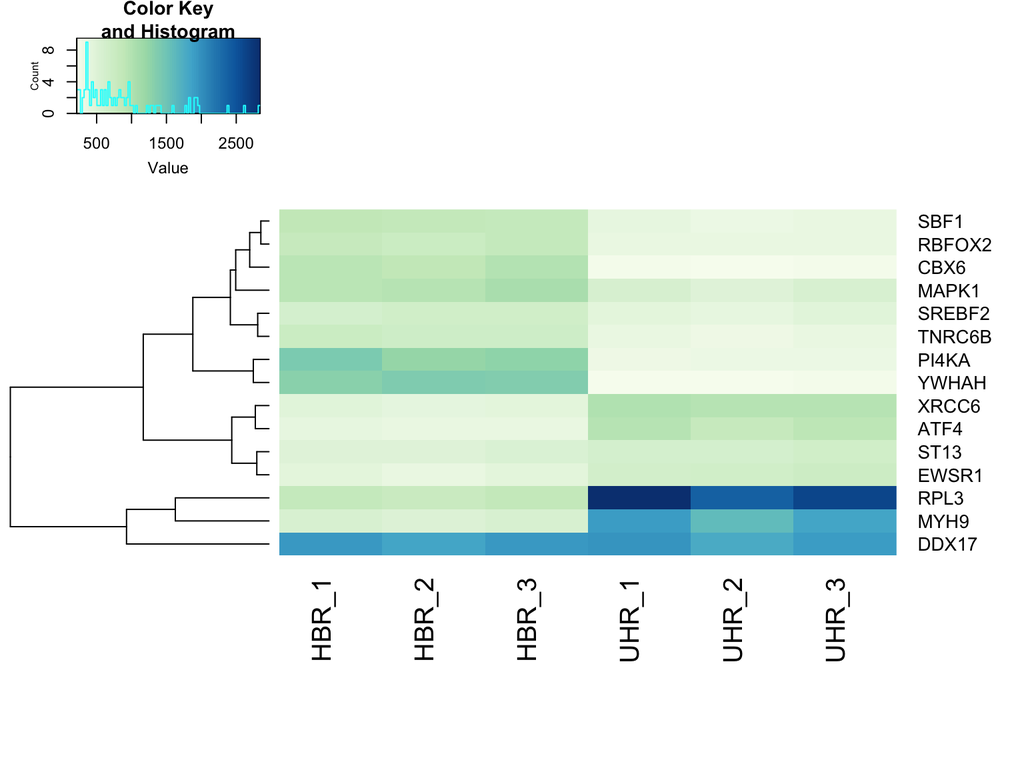

```r
library('RColorBrewer')
library('gplots')

color <- colorRampPalette(brewer.pal(9, 'GnBu'))(100)
select <- order(rowMeans(counts(dds, normalized=TRUE)), decreasing = TRUE)[1:15]
heatmap_genes <- counts(dds, normalized=TRUE)[select,]

rownames(heatmap_genes) <- gsub("\\..*", "", row.names(heatmap_genes))
rownames(heatmap_genes) <- mapIds(org.Hs.eg.db,
                                  keys = row.names(heatmap_genes),
                                  column = "SYMBOL",
                                  keytype = "ENSEMBL",
                                  multiVals = "first")
heatmap.2(heatmap_genes,
          col = color,
          Rowv = TRUE,
          Colv = FALSE,
          scale ='none',
          dendrogram = 'row',
          trace = 'none',
          margin = c(10, 6))
```

## Count table: variance stabilization transformation

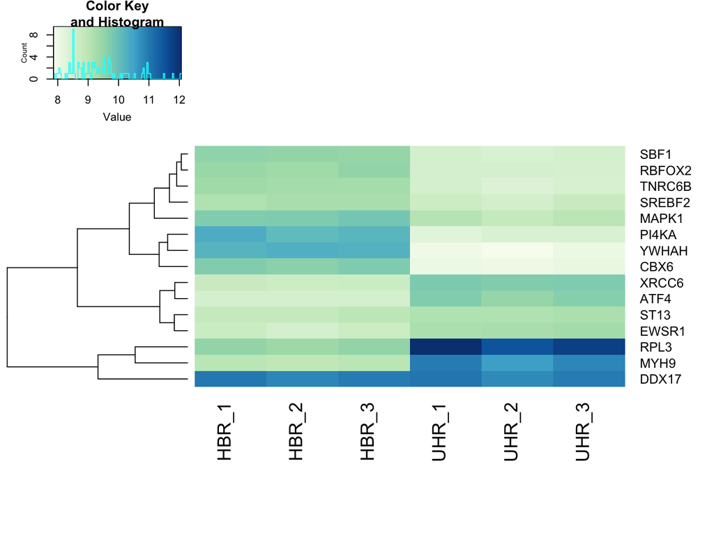

```r
color <- colorRampPalette(brewer.pal(9, 'GnBu'))(100)
select <- order(rowMeans(counts(dds, normalized=TRUE)), decreasing = TRUE)[1:15]

vsd <- varianceStabilizingTransformation(dds, blind = TRUE, fitType = "local")
heatmap_vsd <- assay(vsd)[select,]
rownames(heatmap_vsd) <- gsub("\\..*", "", row.names(heatmap_vsd))
rownames(heatmap_vsd) <- mapIds(org.Hs.eg.db,
                                  keys = row.names(heatmap_vsd),
                                  column = "SYMBOL",
                                  keytype = "ENSEMBL",
                                  multiVals = "first")
heatmap.2(heatmap_vsd,
          col = color,
          Rowv = TRUE,
          Colv = FALSE,
          scale ='none',
          dendrogram ='row',
          trace = 'none',
          margin=c(10, 6))
```

## Log fold change distribution

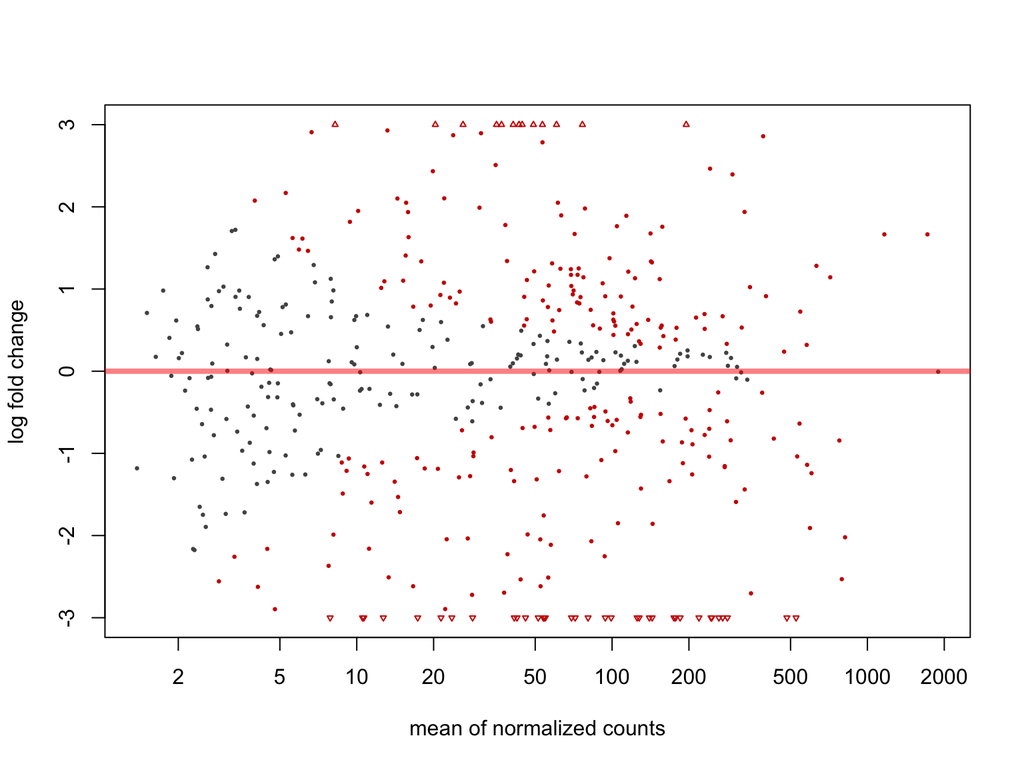

```r
plotMA(res, ylim = c(-3, 3))
```

## Plot Counts

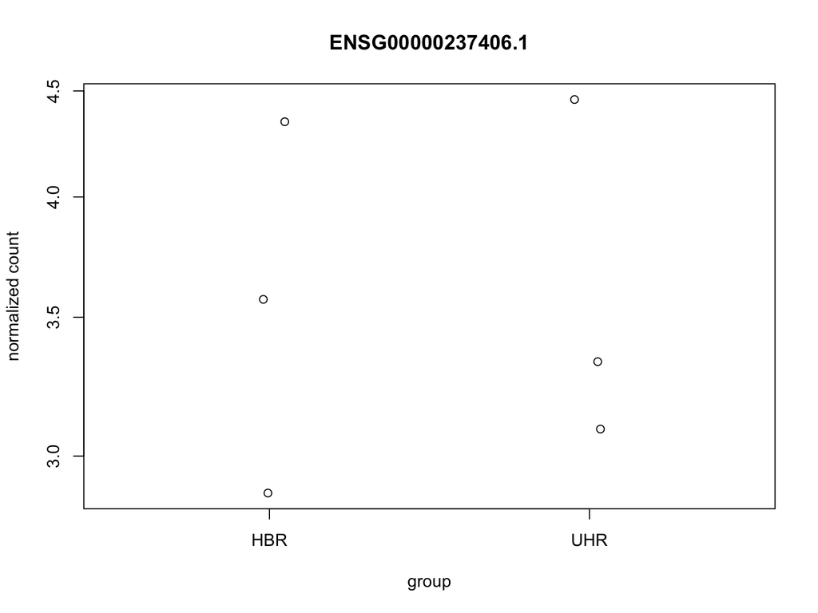

```r
plotCounts(dds, gene = which.max(res$padj), intgroup = "cell_type")
```

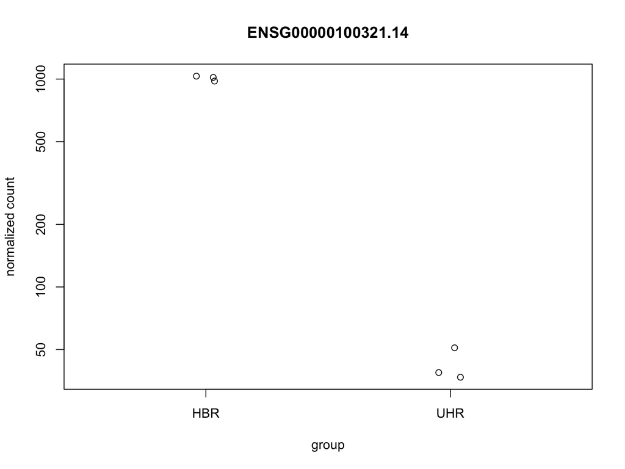

```r
plotCounts(dds, gene = "ENSG00000100321.14", intgroup = "cell_type")
```